# Proj

Checking Data Quality from Replicate measures (same leaf, twice)

```
##   Rep.    AnthDup     AnthSD   ChlDup    ChlSD  FlavDup    FlavSD
## 1   Y1 0.09830189 0.04539806 34.93672 14.55641 1.979969 0.2863768
## 2   Y2 0.09768153 0.04439018 36.59920 14.51963 1.954280 0.2796720
```

```
## Analysis of Variance Table
##
## Response: Dup$Anth
##            Df  Sum Sq   Mean Sq F value Pr(>F)
## Dup$Rep.    1 0.00003 0.0000304  0.0151 0.9023
## Residuals 314 0.63303 0.0020160
```

```
## Analysis of Variance Table
##
## Response: Dup$Chl
##            Df Sum Sq Mean Sq F value Pr(>F)
## Dup$Rep.    1    218  218.33   1.033 0.3102
## Residuals 314  66366  211.36
```

```
## Analysis of Variance Table
##
## Response: Dup$Flav
##            Df  Sum Sq  Mean Sq F value Pr(>F)
## Dup$Rep.    1  0.0521 0.052129  0.6506 0.4205
## Residuals 314 25.1596 0.080126
```

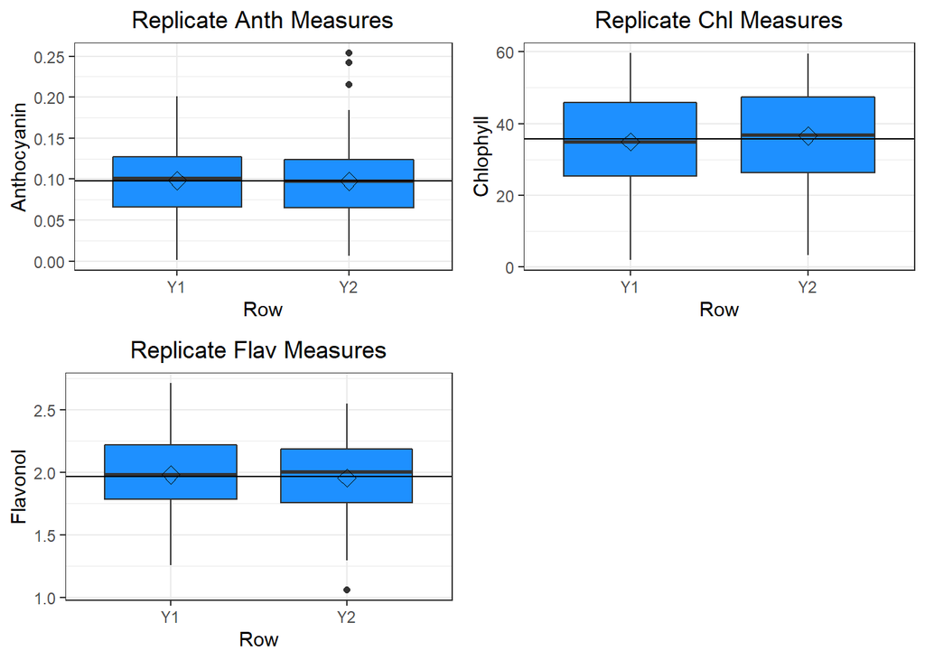

Replicate measures and plots appear to correspond well - indicative that the measurements from the dualex are reliable. Might pay to remove the outliers.

Plots of leaf chemicals across groups

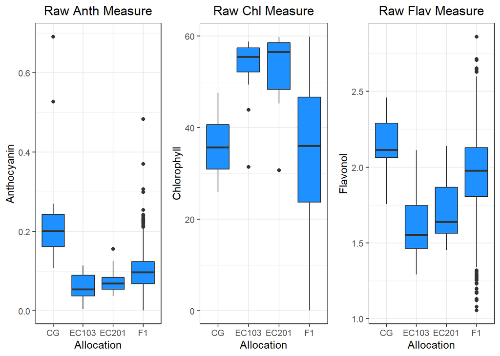

Anthocyanin Crimson Glory(CG) outgroup apparent, F1 population more similar to parental trees.

Chlorophyll F1 very diverse, overlaps with both parent trees and outgroup, more similar median and distrubtion to outgroup.

#Plots of unadjusted F1 chemical

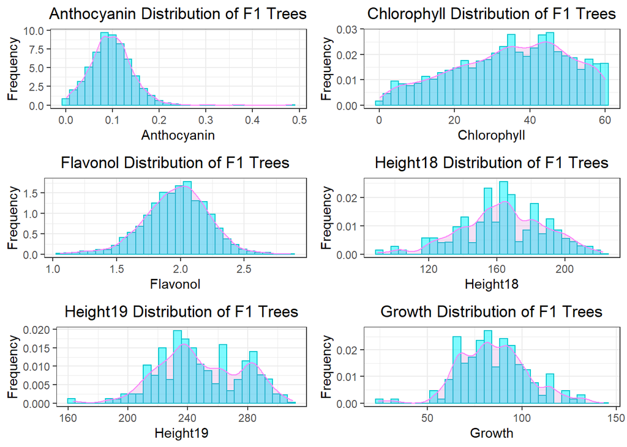

Anothcyanin left bias, long tail

Chlorophyll right bias, truncated

Flavonol typical bell curve with slightly long tails both directions

Height 2018 lumpy normal disitribution

Height 2019 appears to be two overlapping distribitiuons, maybe 3

Growth maybe 3 overlapping populations

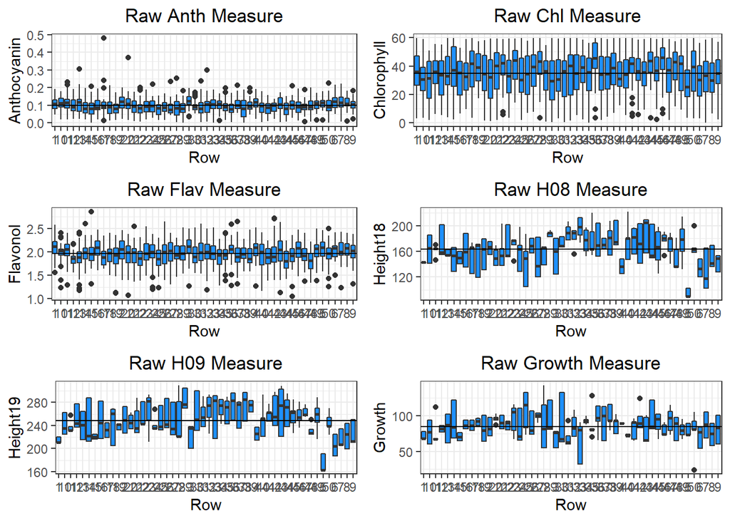

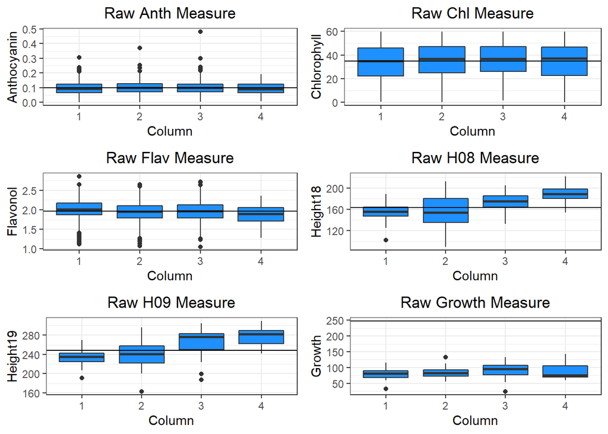

[figure not shown]

```
## Analysis of Variance Table
##
## Response: F1$Anth
##             Df Sum Sq   Mean Sq F value    Pr(>F)
## F1$Row      49 0.2346 0.0047878  2.5717 2.467e-08 ***
## F1$Column    1 0.0020 0.0019565  1.0509    0.3054
## F1$Height    2 0.0520 0.0260053 13.9687 9.587e-07 ***
## Residuals 1739 3.2375 0.0018617
## ---
## Signif. codes:  0 '***' 0.001 '**' 0.01 '*' 0.05 '.' 0.1 ' ' 1
```

```
## Analysis of Variance Table
##
## Response: F1$Chl
##             Df Sum Sq Mean Sq F value    Pr(>F)
## F1$Row      49  21394  436.61  1.9560 0.0001012 ***
## F1$Column    1    470  469.95  2.1054 0.1469578
## F1$Height    2    737  368.69  1.6517 0.1920166
## Residuals 1739 388163  223.21
## ---
## Signif. codes:  0 '***' 0.001 '**' 0.01 '*' 0.05 '.' 0.1 ' ' 1
```

```
## Analysis of Variance Table
##
## Response: F1$Flav
##             Df  Sum Sq Mean Sq F value    Pr(>F)
## F1$Row      49   8.215 0.16765  2.9026 1.751e-10 ***
## F1$Column    1   1.379 1.37854 23.8681 1.126e-06 ***
## Residuals 1741 100.554 0.05776
## ---
## Signif. codes:  0 '***' 0.001 '**' 0.01 '*' 0.05 '.' 0.1 ' ' 1
```

```
## Analysis of Variance Table
##
## Response: F1$Height08
##             Df Sum Sq Mean Sq F value    Pr(>F)
## F1$Row      49 493101   10063  42.056 < 2.2e-16 ***
## F1$Column    1 154439  154439 645.422 < 2.2e-16 ***
## Residuals 1673 400321     239
## ---
## Signif. codes:  0 '***' 0.001 '**' 0.01 '*' 0.05 '.' 0.1 ' ' 1
```

```
## Analysis of Variance Table
##
## Response: as.numeric(F1$Height09)
##             Df Sum Sq Mean Sq  F value    Pr(>F)
## F1$Row      49 626751   12791   51.649 < 2.2e-16 ***
## F1$Column    1 275536  275536 1112.606 < 2.2e-16 ***
## Residuals 1672 414069     248
## ---
## Signif. codes:  0 '***' 0.001 '**' 0.01 '*' 0.05 '.' 0.1 ' ' 1
```

```
## Analysis of Variance Table
##
## Response: as.numeric(F1$Growth)
##             Df Sum Sq Mean Sq F value    Pr(>F)
## F1$Row      49 145650  2972.5  12.725 < 2.2e-16 ***
## F1$Column    1  17049 17049.2  72.985 < 2.2e-16 ***
## Residuals 1672 390575   233.6
## ---
## Signif. codes:  0 '***' 0.001 '**' 0.01 '*' 0.05 '.' 0.1 ' ' 1
```

Anthocyanin Row effects, minimal effect of Column

Chlorophyll Significant Row effect, no Column effect.

Flavonol Significant row and column effects

Height 2018 Very Significant effect of row and column

Height 2019 Very Significant effect of row and column

Growth difference (Height 2019- Height 2018) Very Significant effect of row and column

```
##      Column Row Tree.ID Allocation Rep. measure Height Flower Flower.Level
## 964       2  13   IN4E4         F1    N       7      M      N            0
## 1333      3   9   IN4FM         F1    N      11      H      N            0
##         Chl  Flav  Anth   NBI Height08 Height09 Growth AnthRowMeans ChlRowMeans
## 964  18.511 1.401 0.370 13.21      138      234     96    0.1105227    31.51561
## 1333 59.122 1.640 0.483 36.05      166      245     79    0.1163182    32.12650
##      FlavRowMeans H18RowMeans H19RowMeans AnthColMeans ChlColMeans FlavColMeans
## 964      1.933068    151.0000       246.5   0.09924281    35.39257     1.944405
## 1333     1.886773    146.6957       232.0   0.09897588    36.04402     1.960649
##      H18ColMeans H19ColMeans   AdjAnth
## 964     157.0018    241.0717 0.3544711
## 1333    175.1734    267.4482 0.4619425
```

```
## Analysis of Variance Table
##
## Response: F1$AdjAnth
##             Df  Sum Sq    Mean Sq F value Pr(>F)
## F1$Row       1 0.00056 0.00056489  0.3274 0.5672
## F1$Column    1 0.00000 0.00000029  0.0002 0.9896
## Residuals 1787 3.08301 0.00172524
```

```
## Analysis of Variance Table
##
## Response: F1$AdjChl
##             Df Sum Sq Mean Sq F value Pr(>F)
## F1$Row       1      1   0.890  0.0041 0.9489
## F1$Column    1     72  72.407  0.3346 0.5630
## Residuals 1787 386674 216.382
```

```
## Analysis of Variance Table
##
## Response: F1$AdjFlav
##             Df Sum Sq  Mean Sq F value Pr(>F)
## F1$Row       1  0.019 0.019106  0.3427 0.5583
## F1$Column    1  0.008 0.007930  0.1422 0.7061
## Residuals 1787 99.624 0.055749
```

```
## Analysis of Variance Table
##
## Response: F1$AdjH18
##             Df Sum Sq Mean Sq F value    Pr(>F)
## F1$Row       1   2625  2625.3  11.005 0.0009277 ***
## F1$Column    1   6285  6285.4  26.347 3.176e-07 ***
## Residuals 1719 410084   238.6
## ---
## Signif. codes:  0 '***' 0.001 '**' 0.01 '*' 0.05 '.' 0.1 ' ' 1
```

```
## Analysis of Variance Table
##
## Response: F1$AdjH19
##             Df Sum Sq Mean Sq F value    Pr(>F)
## F1$Row       1   3064  3063.9  12.788 0.0003586 ***
## F1$Column    1  14757 14756.5  61.589 7.385e-15 ***
## Residuals 1718 411630   239.6
## ---
## Signif. codes:  0 '***' 0.001 '**' 0.01 '*' 0.05 '.' 0.1 ' ' 1
```

```
## Analysis of Variance Table
##
## Response: as.numeric(F1$Growth)
##             Df Sum Sq Mean Sq F value   Pr(>F)
## F1$Row       1     26   26.07  0.1178 0.731482
## F1$Column    1   1852 1851.64  8.3672 0.003869 **
## Residuals 1718 380187  221.30
## ---
## Signif. codes:  0 '***' 0.001 '**' 0.01 '*' 0.05 '.' 0.1 ' ' 1
```

Adjust height row and column effects

```
## Analysis of Variance Table
##
## Response: F1$AdjH182
##             Df Sum Sq Mean Sq F value Pr(>F)
## F1$Row       1    174 173.971  0.7742 0.3790
## F1$Column    1      7   6.782  0.0302 0.8621
## Residuals 1718 386029 224.697
```

```
## Analysis of Variance Table
##
## Response: F1$AdjH192
##             Df Sum Sq Mean Sq F value    Pr(>F)
## F1$Row       1    423  423.06  1.8915 0.1692147
## F1$Column    1   3107 3107.07 13.8915 0.0001999 ***
## Residuals 1718 384260  223.67
## ---
## Signif. codes:  0 '***' 0.001 '**' 0.01 '*' 0.05 '.' 0.1 ' ' 1
```

```
## Analysis of Variance Table
##
## Response: as.numeric(F1$Growth)
##             Df  Sum Sq Mean Sq  F value    Pr(>F)
## F1$Row       1   54.44   54.44   39.712 3.731e-10 ***
## F1$Column    1 2823.51 2823.51 2059.493 < 2.2e-16 ***
## Residuals 1718 2355.33    1.37
## ---
## Signif. codes:  0 '***' 0.001 '**' 0.01 '*' 0.05 '.' 0.1 ' ' 1
```

```
## Analysis of Variance Table
##
## Response: F1$AdjH193
##             Df Sum Sq Mean Sq F value Pr(>F)
## F1$Row       1     63  63.269  0.2839 0.5942
## F1$Column    1    210 209.574  0.9403 0.3323
## Residuals 1718 382892 222.871
```

```
## Analysis of Variance Table
##
## Response: as.numeric(F1$Growth)
##             Df  Sum Sq Mean Sq  F value    Pr(>F)
## F1$Row       1   54.44   54.44   39.712 3.731e-10 ***
## F1$Column    1 2823.51 2823.51 2059.493 < 2.2e-16 ***
## Residuals 1718 2355.33    1.37
## ---
## Signif. codes:  0 '***' 0.001 '**' 0.01 '*' 0.05 '.' 0.1 ' ' 1
```

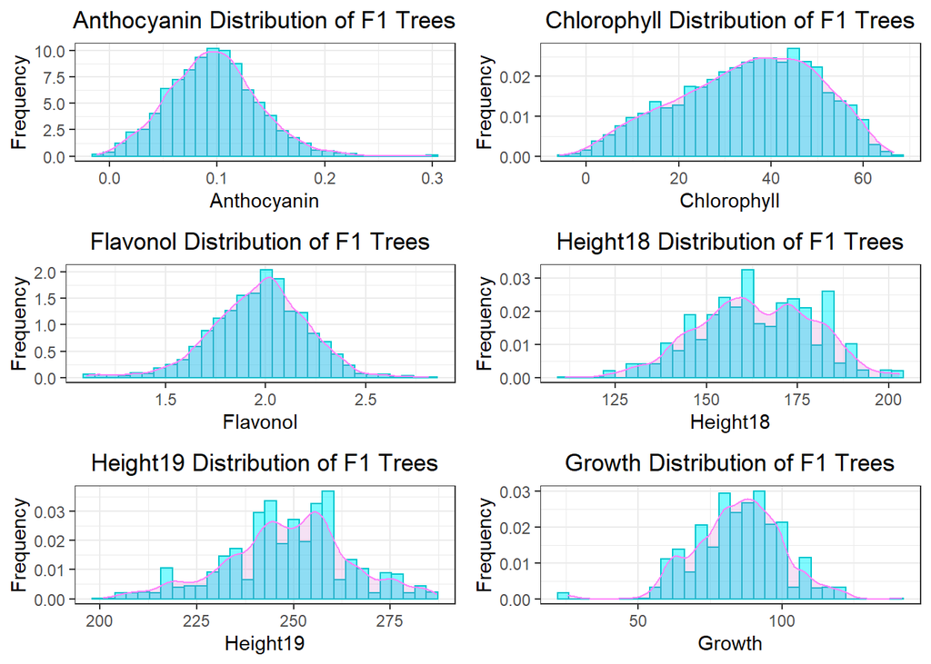

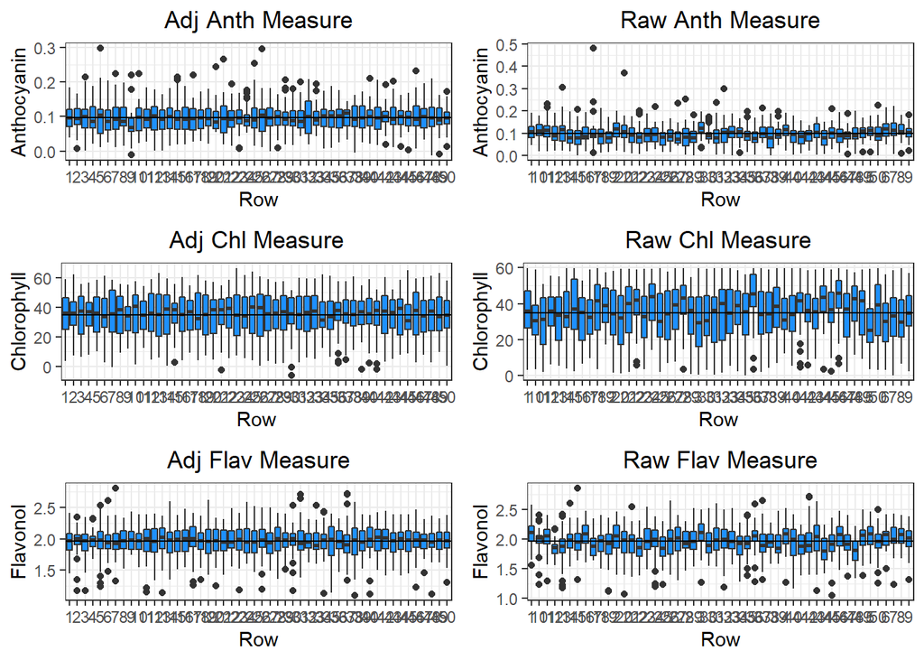

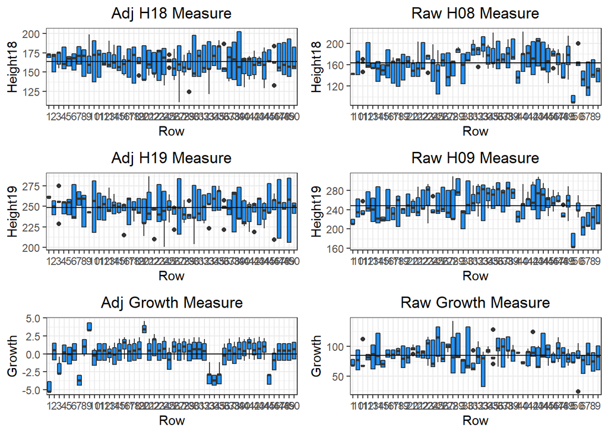

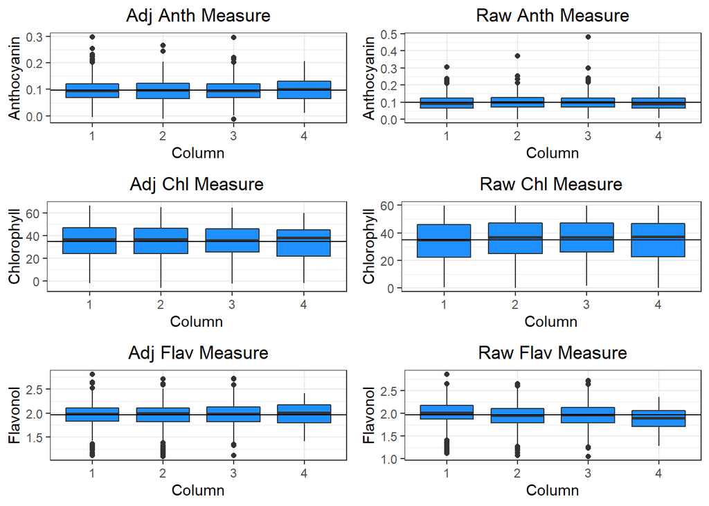

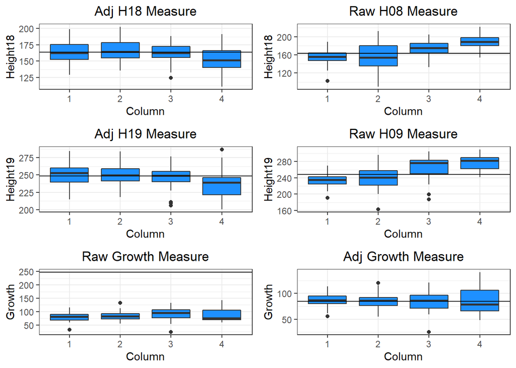

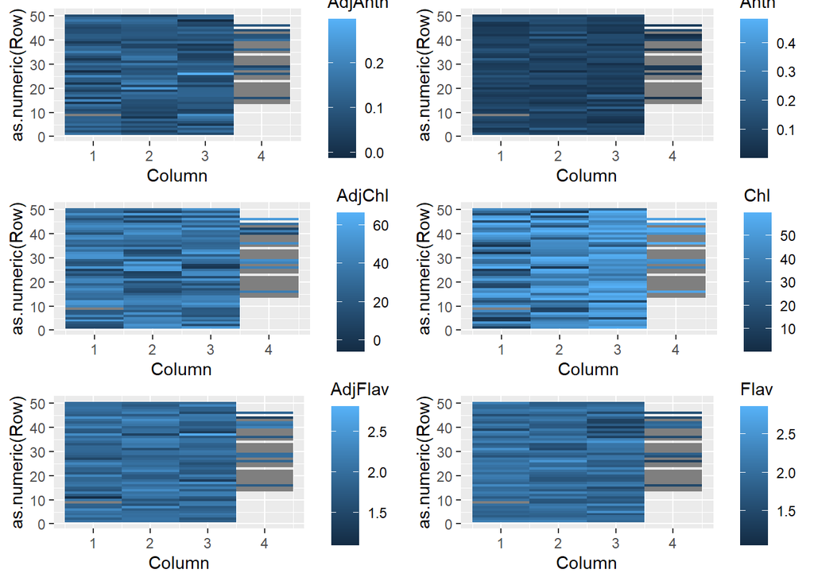

[figure not shown]